# Mobile Internet Traffic Peak Forecast

In this paper we apply Time Series Forecasting to predict the growth of the Mobile Internet Traffic of a Mobile Network Operator (MNO).

The traffic peak is expressed in Gbps and it is a collection of real data from March to October 2016, including 2G, 3G and 4G traffic, more precisely we want to predict the growth of peak hour traffic for capacity planning reasons, in order to answer to the question: When does the MNO need to upgrade equipment like network nodes or monitoring tools before they reach their maximum capacity?

[output not shown]

```r
# Create the model. Mbps are transformed in Gbps
mod_max_log <- tslm(log(y/1024) ~ trend)
summary(mod_max_log)
```

```
Call:
tslm(formula = log(y/1024) ~ trend)

Residuals:
      Min        1Q    Median        3Q       Max
-0.183567 -0.029576  0.001121  0.030202  0.110370

Coefficients:
             Estimate Std. Error t value Pr(>|t|)
(Intercept) 4.618e+00  6.162e-03  749.53   <2e-16 ***
trend       1.697e-03  4.645e-05   36.52   <2e-16 ***
---
Signif. codes:  0 â€˜***â€™ 0.001 â€˜**â€™ 0.01 â€˜*â€™ 0.05 â€˜.â€™ 0.1 â€˜ â€™ 1

Residual standard error: 0.04647 on 227 degrees of freedom
Multiple R-squared:  0.8546,    Adjusted R-squared:  0.8539
F-statistic:  1334 on 1 and 227 DF,  p-value: < 2.2e-16
```

As expected the p-values clearly means that time and traffic speed growth are correlated (reject NULL hypothesis), moreover the std. error od the intercept and trend shows that the Estimate values are good approximation and will be used in the following.

[interactive chart not shown]

Now let’s verify the model against new values recorded after the model was built.

```r
# New Data is available in a new folder
setwd("./New Data/")
```

[output not shown]

```r
# Apply the same calculation, to obtain the maximum per day
# List all files
GnGP <- list.files(pattern = "GnGp_IP_Network")
S <- list.files(pattern = "S_IP_Network")
S1 <- list.files(pattern = "S1_IP_Network")
S5S8 <- list.files(pattern = "S5_S8_IP_Network")
IP <- list.files(pattern = "_IP_Network")
Traffic_all <- data.frame()
Tr_names <- names(as.data.frame(fread(IP[1])))
for(i in IP) {

        temp <- as.data.frame(fread(i))
        names(temp) <- Tr_names
 #       l <- list(Traffic_all, temp)
        Traffic_all <- base::rbind(Traffic_all,temp)
}
# Summarise by date summing the Speed
Traffic <- aggregate(Traffic_all$`Speed [Mbps]` ~ Traffic_all$date,
                     data = Traffic_all, sum)
names(Traffic) <- c("date", "Speed")
# Traffic3G <- fread("Data_Traffic_Network_summary_GnGp_IP_Network.csv")
# Traffic4G <- fread("Data_Traffic_Network_summary_S1_IP_Network.csv")
# Traffic <- inner_join(Traffic3G,Traffic4G, by ="date")[,c(1,3,16)]
# Traffic <- mutate(Traffic, Speed = Traffic$`Speed [Mbps].x` + Traffic$`Speed [Mbps].y`)
Traffic_date <- strptime(Traffic$date, "%m/%d/%Y %H:%M:%S")
Traffic_df <- data.table(date = Traffic_date, Speed = Traffic$Speed)
```

```
POSIXlt column type detected and converted to POSIXct. We do not recommend use of POSIXlt at all because it uses 40 bytes to store one date.
```

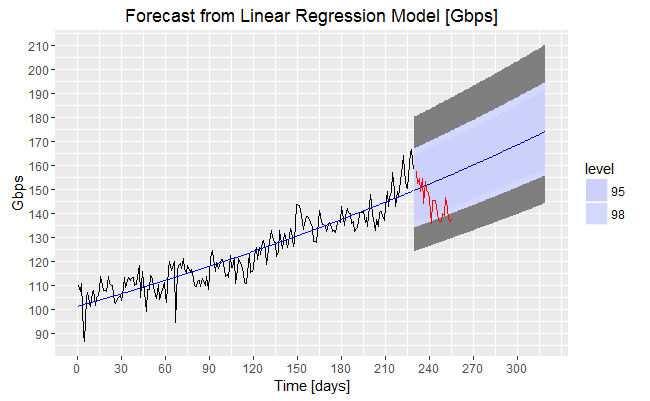

```r
#Traffic_ord <- setorder(Traffic_df, date)[-1,]
Traffic_ord <- Traffic_df
# TRAFFIC ANALYSIS
Traffic_XTS <- xts(as.numeric(Traffic_ord$Speed), order.by = Traffic_ord$date)
########### Calculate the MAXIMUM #####################
Traffic_Max <- apply.daily(Traffic_XTS,max)
df_Max <- data.frame(Traffic_Max[,1], Time = index(Traffic_Max))
names(df_Max) <- c("Speed", "Time")
# Remove the last point as the recorded value is not complete
df_Max <- df_Max[1:25,]
y <- ts(df_Max$Speed,frequency = 1, start = 231) / 1024
 PFORE + geom_line(aes(x=c(231:255), y = y), col = "red")
```